# Analyzing Rainwater Harvesting Time Series Data

Author

Avery Eastman

hw2data.csv has the daily rainfall from the Fort Collins weather station for this summer. Your task is to calculate how much rainfall would be in a rain barrel each day based on the rain inputs (supply) and the irrigation use (demand).

### Steps:

1. Calculate the volume of water that could be harvested each day, assuming a roof area of 431 ft2 and an efficiency of 0.93.
2. Assume the demand (water use for irrigation) is 7 gallons per day, and irrigation is only used on days without rain
3. Start calculations for volume of water in the barrel on the first day with rain. The volume of water cannot exceed the barrel capacity, which is 48 gallons.
4. After the first day with rain, the volume of water in the barrel is the previous day’s volume + current day rainfall input volume – demand volume
5. The volume in the barrel cannot be negative, so if the volume drops below zero on any day, set that day’s volume to 0

### Deliverables:

```r
library(tidyverse)
library(lubridate)
library(ggplot2)
```

```r
rainwater_data = read_csv('hw2data.csv')

clean_data <- na.omit(rainwater_data)

capacity = 48

clean_data$date <- mdy(clean_data$date)

clean_data$demand <- ifelse(clean_data$P_in>0,0,7)

clean_data$volume <- clean_data$P_in*431*0.93*7.48/12

clean_data$vol_net <- 0

for (i in 2:nrow(clean_data)) {
  clean_data[i,'vol_net']=ifelse((clean_data[i-1,'vol_net']+clean_data[i,'volume'])<=capacity,
                                 clean_data[i-1,'vol_net']+clean_data[i,'volume']-clean_data[i,'demand'],
                                 capacity)
  clean_data[i,'vol_net']=ifelse(clean_data[i,'vol_net']<0,0,clean_data[i,'vol_net'])
}
```

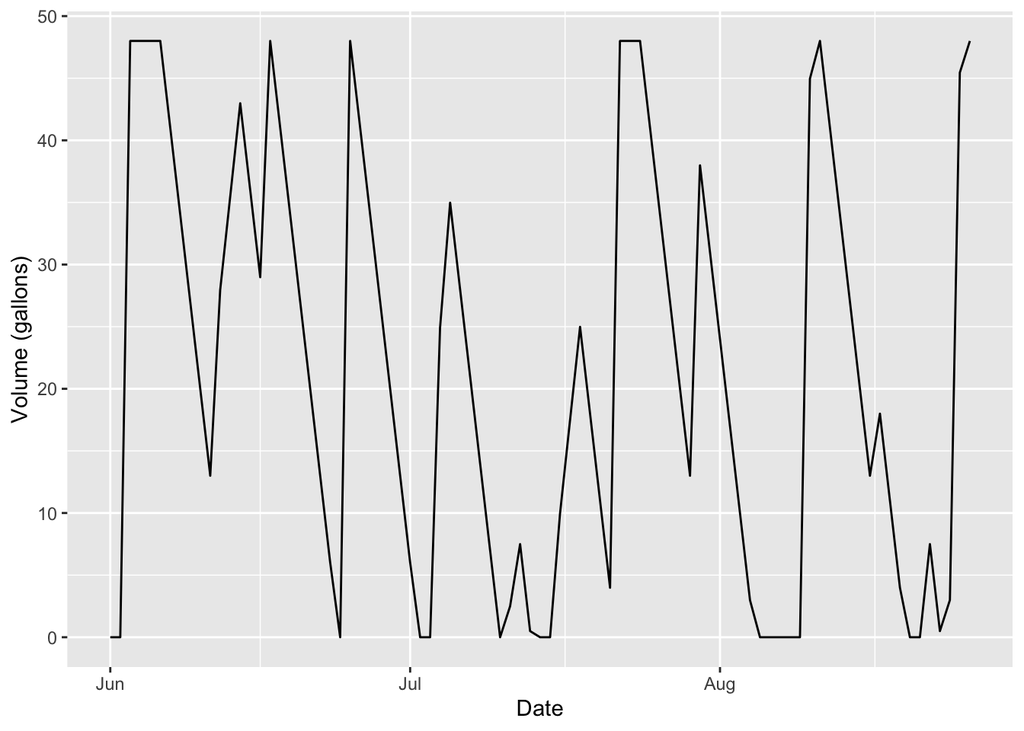

```r
ggplot()+geom_line(data = clean_data, aes(x=date, y=vol_net))+
  ylab('Volume (gallons)')+
  xlab('Date')
```

Figure 1. Daily volume of water collected over summer 2025 in Fort Collins with a 48-gallon rain barrel, given a 7 gallons/day water demand.

```r
days_empty_48 = sum(clean_data$vol_net == 0)
```

```r
capacity_2nd = 100

data_100 <- clean_data

data_100$vol_net <- 0

for (i in 2:nrow(data_100)) {
  data_100[i,'vol_net']=ifelse((data_100[i-1,'vol_net']+data_100[i,'volume'])<=capacity_2nd,
                               data_100[i-1,'vol_net']+data_100[i,'volume']-data_100[i,'demand'],
                                 capacity_2nd)
  data_100[i,'vol_net']=ifelse(data_100[i,'vol_net']<0,0,data_100[i,'vol_net'])
}
```

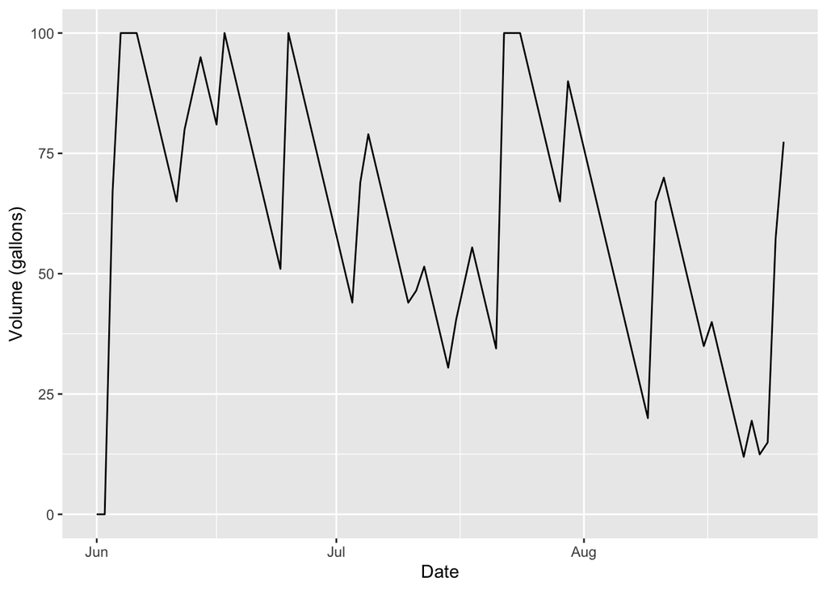

```r
ggplot()+geom_line(data = data_100, aes(x=date, y=vol_net))+
  ylab('Volume (gallons)')+
  xlab('Date')
```

Figure 2. Daily volume of water collected over summer 2025 in Fort Collins with a 100-gallon rain barrel, given a 7 gallons/day water demand.

```r
days_empty_100 = sum(data_100$vol_net == 0)
```

The number of days that the rain barrel is empty for the 48-gallon barrel is 15 days. The number of days that the rain barrel is empty for the 100-gallon barrel is 2 days.